# Proyecto final

Predicción del precio del Bitcoin y Ethereum utilizando series de tiempo.

Edwin Flores

2021-04-11

# 1 **Compresión del negocio**

Sin duda alguna, los meses anteriores han sido muy importantes en la bolsa de criptomonedas debido al alza continua, principalmente del Bitcoin. Noticias van y vienen sobre este tema y esto genera muchas dudas en las personas que quieren invertir en este tipo de activos.

Teniendo en cuenta lo anterior, en el presente proyecto intenta predecir el precio de dos criptomonedas, Bitcoin y Ethereum.

Estas dos criptomonedas se encuentran entre las criptomonedas de mejor rendimiento y que han tenido un alza importante en los últimos meses.

Para esto será necesario aplicar los conocimientos obtenidos del programa de minería de datos, específicamente en el área de series de tiempo.

**¿Qué es Bitcoin?**

*Bitcoin es una red consensuada que permite un nuevo sistema de pago y una moneda completamente digital. Es la primera red entre pares de pago descentralizado impulsado por sus usuarios sin una autoridad central o intermediarios. Desde un punto de vista de usuario, Bitcoin es como dinero para Internet. Bitcoin puede ser el único sistema de contabilidad triple existente.*

Desde la perspectiva del usuario, Bitcoin no es más que una aplicación móvil o de escritorio que provee un monedero Bitcoin personal y permite al usuario enviar y recibir bitcoins con el. Así es como funciona Bitcoin para la mayoría de los usuarios.

Detrás de las cámaras, la red Bitcoin comparte una contabilidad pública llamada “block chain”. Esta contabilidad contiene cada transacción procesada, permitiendo verificar la validez de cada transacción. La autenticidad de cada transacción esta protegida por firmas digitales correspondientes a las direcciones de envío, permitiendo a todos los usuarios tener control total al enviar Bitcoins desde sus direcciones Bitcoin. Además, cualquiera puede procesar una transacción usando el poder computacional de hardware especializado y conseguir una recompensa en Bitcoins por este servicio. Esto es comúnmente llamado “mining” o minería. Para aprender más sobre Bitcoin, puedes consultar la página dedicada y el documento original.

Fuente: https://bitcoin.org/es

**¿Qué es Ethereum?**

Ethereum es una tecnología que te permite enviar criptomonedas a cualquier persona por una pequeña comisión. También potencia aplicaciones que cualquiera puede usar y nadie puede derribar.

Es la blockchain programable del mundo.

Ethereum se construye sobre la innovación de Bitcoin, pero con grandes diferencias.

Ambos utilizar dinero digital sin proveedores de pago o bancos. Pero Ethereum es programable, así que también puedes utilizarlo para diferentes activos digitales, incluido Bitcoin.

Esto también significa que Ethereum es más que pagos. Ethereum es un mercado de servicios financieros, juegos y aplicaciones que no pueden robar tu información o censurarte.

Es habitual confundir Ethereum y ETH. Ethereum es la cadena de bloques y ETH (Ether) es el activo principal de Ethereum.

Fuente: https://ethereum.org/es/

## 1.1 **Objetivo General**

- Predecir el precio de criptomonedas del Bitcoin y Ethereum en dólares

## 1.2 **Objetivos específicos**

- Utilizar la mayor cantidad de métodos predictivos para series de tiempo vistos en clase, y compararlos.
- Seleccionar el mejor método de predicción para Bitcoin como para Ethereum.

# 2 **Compresión de los datos**

El historial de datos a utilizar comprende desde Octubre 2014 a la fecha para Bitcoin y desde Septiembre del 2015 a la fecha para el Ethereum.

Las variables (columnas) en ambas tablas de datos serían las siguientes:  
a. Date  
b. Open  
c. High  
d. Low  
e. Close  
f. Adj Close  
g. Volume

Los individuos (filas) comprenden información histórica diaria desde 2014 para Bitcoin y desde 2015 para Ethereum

Para la tabla de datos, la cual comprende información histórica diaria del Bitcoin, la dimensión sería de 2,332 individuos y 7 variables. Si se agrupa por mes tendriamos un total de 78 individuos.

Mientras para la tabla de datos, la cual comprende información histórica diaria del Ethereum, la dimensión sería de 2,008 individuos y 7 variables. Si se agrupa por mes tendriamos un total de 67 individuos.

La variable a predecir tanto para el Bitcoin como para el Ethereum sería la variable Close. Esto porque, es la variable que indica cual fue el precio de cierre de estas criptomonedas.

## 2.1 **Recolección de los datos**

La recolección de datos se realiza desde la plataforma de *yahoo finance*, especificamente de las siguientes páginas web.  
a. https://finance.yahoo.com/quote/BTC-USD

[figure not shown]

b. https://finance.yahoo.com/quote/ETH-USD

[figure not shown]

# 3 **Bitcoin (BTC)**

## 3.1 **Descripción de los datos**

### 3.1.1 Carga de datos

Se realiza la carga del conjunto de datos de la inforamción de Bitcoin. Adicionlamnete se define el patron de estacionalidad anual con fecruencia 12 debido a que los datos son mensuales por cada año.

```r
library(DT)
Sys.setlocale("LC_TIME", "Spanish")
```

```
## [1] "Spanish_Spain.1252"
```

```r
dataset.btc <- read.csv(file = "datos/BTC-USD_M.csv", head = TRUE, sep=",")
DT::datatable(dataset.btc)
```

|  | Date | Open | High | Low | Close | Adj.Close | Volume |
| --- | --- | --- | --- | --- | --- | --- | --- |
| 1 | 2014-10-01 | 387.427002 | 411.697998 | 289.29599 | 338.321014 | 338.321014 | 902994450 |
| 2 | 2014-11-01 | 338.649994 | 457.092987 | 320.626007 | 378.046997 | 378.046997 | 659733360 |
| 3 | 2014-12-01 | 378.248993 | 384.037994 | 304.231995 | 320.192993 | 320.192993 | 553102310 |
| 4 | 2015-01-01 | 320.434998 | 320.434998 | 171.509995 | 217.464005 | 217.464005 | 1098811912 |
| 5 | 2015-02-01 | 216.867004 | 265.610992 | 212.014999 | 254.263 | 254.263 | 711518700 |
| 6 | 2015-03-01 | 254.283005 | 300.044006 | 236.514999 | 244.223999 | 244.223999 | 959098300 |
| 7 | 2015-04-01 | 244.223007 | 261.798004 | 214.873993 | 236.145004 | 236.145004 | 672338700 |
| 8 | 2015-05-01 | 235.938995 | 247.804001 | 228.572998 | 230.190002 | 230.190002 | 568122600 |
| 9 | 2015-06-01 | 230.233002 | 267.867004 | 221.296005 | 263.071991 | 263.071991 | 629780200 |
| 10 | 2015-07-01 | 263.345001 | 314.394012 | 253.505005 | 284.649994 | 284.649994 | 999892200 |

[output cut: 68 more lines]

```r
valor_frecuencia = 12
```

Seguidamente se presentará la descripción de los datos para Bitcoin

- Date: Columna que muestra la fecha en formato yyyy-mm-dd
- Open: Precio de apertura
- High: Precio más alto
- Low: Precio más bajo
- Close: Precio de clausura
- Adj Close: Precio de clausura con ajustes
- Volume: Volumen de monedas intercambiadas

## 3.2 **Exploración de los datos**

### 3.2.1 Exploración de los datos

```r
summary(dataset.btc)
```

```
##          Date         Open              High              Low
##  2014-10-01: 1   Min.   :  216.9   Min.   :  247.8   Min.   :  171.5
##  2014-11-01: 1   1st Qu.:  469.1   1st Qu.:  572.0   1st Qu.:  459.4
##  2014-12-01: 1   Median : 4064.9   Median : 4855.5   Median : 3492.9
##  2015-01-01: 1   Mean   : 5954.1   Mean   : 7803.2   Mean   : 5282.3
##  2015-02-01: 1   3rd Qu.: 9027.7   3rd Qu.:10155.1   3rd Qu.: 7046.8
##  2015-03-01: 1   Max.   :45159.5   Max.   :61683.9   Max.   :45115.1
##  (Other)   :72
##      Close           Adj.Close           Volume
##  Min.   :  217.5   Min.   :  217.5   Min.   :    553102310
##  1st Qu.:  542.4   1st Qu.:  542.4   1st Qu.:   2191825746
##  Median : 4222.1   Median : 4222.1   Median : 129979774792
##  Mean   : 6704.7   Mean   : 6704.7   Mean   : 344984320624
##  3rd Qu.: 9184.2   3rd Qu.: 9184.2   3rd Qu.: 582857185838
##  Max.   :58918.8   Max.   :58918.8   Max.   :2267152936680
##
```

```r
str(dataset.btc)
```

```
## 'data.frame':    78 obs. of  7 variables:
##  $ Date     : Factor w/ 78 levels "2014-10-01","2014-11-01",..: 1 2 3 4 5 6 7 8 9 10 ...
##  $ Open     : num  387 339 378 320 217 ...
##  $ High     : num  412 457 384 320 266 ...
##  $ Low      : num  289 321 304 172 212 ...
##  $ Close    : num  338 378 320 217 254 ...
##  $ Adj.Close: num  338 378 320 217 254 ...
##  $ Volume   : num  902994450 659733360 553102310 1098811912 711518700 ...
```

## 3.3 **Preparación de los datos**

### 3.3.1 Formateo de los datos

```r
library(lubridate)

dataset.btc[dataset.btc == 'null'] <- NA
dataset.btc$Date      <- ymd(dataset.btc$Date)
dataset.btc$Open      <- as.numeric(as.character(dataset.btc$Open))
dataset.btc$High      <- as.numeric(as.character(dataset.btc$High))
dataset.btc$Low       <- as.numeric(as.character(dataset.btc$Low))
dataset.btc$Close     <- as.numeric(as.character(dataset.btc$Close))
dataset.btc$Adj.Close <- as.numeric(as.character(dataset.btc$Adj.Close))
dataset.btc$Volume    <- as.numeric(as.character(dataset.btc$Volume))
DT::datatable(dataset.btc)
```

|  | Date | Open | High | Low | Close | Adj.Close | Volume |
| --- | --- | --- | --- | --- | --- | --- | --- |
| 1 | 2014-10-01 | 387.427002 | 411.697998 | 289.29599 | 338.321014 | 338.321014 | 902994450 |
| 2 | 2014-11-01 | 338.649994 | 457.092987 | 320.626007 | 378.046997 | 378.046997 | 659733360 |
| 3 | 2014-12-01 | 378.248993 | 384.037994 | 304.231995 | 320.192993 | 320.192993 | 553102310 |
| 4 | 2015-01-01 | 320.434998 | 320.434998 | 171.509995 | 217.464005 | 217.464005 | 1098811912 |
| 5 | 2015-02-01 | 216.867004 | 265.610992 | 212.014999 | 254.263 | 254.263 | 711518700 |
| 6 | 2015-03-01 | 254.283005 | 300.044006 | 236.514999 | 244.223999 | 244.223999 | 959098300 |
| 7 | 2015-04-01 | 244.223007 | 261.798004 | 214.873993 | 236.145004 | 236.145004 | 672338700 |
| 8 | 2015-05-01 | 235.938995 | 247.804001 | 228.572998 | 230.190002 | 230.190002 | 568122600 |
| 9 | 2015-06-01 | 230.233002 | 267.867004 | 221.296005 | 263.071991 | 263.071991 | 629780200 |
| 10 | 2015-07-01 | 263.345001 | 314.394012 | 253.505005 | 284.649994 | 284.649994 | 999892200 |

[output cut: 68 more lines]

### 3.3.2 Correción de fechas e imputación

```r
library(dplyr)

fecha.inicio <- dataset.btc$Date[1]
fecha.final  <- dataset.btc$Date[nrow(dataset.btc)]

total.fechas <- seq(fecha.inicio, fecha.final, by = "month")

faltan.fechas <- total.fechas[!total.fechas %in% dataset.btc$Date]
faltan.fechas
```

```
## Date of length 0
```

```r
dataset.btc <- dplyr::union_all(dataset.btc, data.frame(Date = faltan.fechas))
dataset.btc <- dataset.btc[order(dataset.btc$Date), ]

dataset.btc$Open[is.na(dataset.btc$Open)] <- mean(dataset.btc$Open, na.rm = T)
dataset.btc$High[is.na(dataset.btc$High)] <- mean(dataset.btc$High, na.rm = T)
dataset.btc$Low[is.na(dataset.btc$Low)] <- mean(dataset.btc$Low, na.rm = T)
dataset.btc$Close[is.na(dataset.btc$Close)] <- mean(dataset.btc$Close, na.rm = T)
dataset.btc$Adj.Close[is.na(dataset.btc$Adj.Close)] <- mean(dataset.btc$Adj.Close, na.rm = T)
dataset.btc$Volume[is.na(dataset.btc$Volume)] <- mean(dataset.btc$Volume, na.rm = T)

summary(dataset.btc)
```

```
##       Date                 Open              High              Low
##  Min.   :2014-10-01   Min.   :  216.9   Min.   :  247.8   Min.   :  171.5
##  1st Qu.:2016-05-08   1st Qu.:  469.1   1st Qu.:  572.0   1st Qu.:  459.4
##  Median :2017-12-16   Median : 4064.9   Median : 4855.5   Median : 3492.9
##  Mean   :2017-12-15   Mean   : 5954.1   Mean   : 7803.2   Mean   : 5282.3
##  3rd Qu.:2019-07-24   3rd Qu.: 9027.7   3rd Qu.:10155.1   3rd Qu.: 7046.8
##  Max.   :2021-03-01   Max.   :45159.5   Max.   :61683.9   Max.   :45115.1
##      Close           Adj.Close           Volume
##  Min.   :  217.5   Min.   :  217.5   Min.   :    553102310
##  1st Qu.:  542.4   1st Qu.:  542.4   1st Qu.:   2191825746
##  Median : 4222.1   Median : 4222.1   Median : 129979774792
##  Mean   : 6704.7   Mean   : 6704.7   Mean   : 344984320624
##  3rd Qu.: 9184.2   3rd Qu.: 9184.2   3rd Qu.: 582857185838
##  Max.   :58918.8   Max.   :58918.8   Max.   :2267152936680
```

### 3.3.3 Normalidad de la serie

```r
library(ggplot2)
library(tseries)

dia.inicio <- which(dataset.btc$Date == "2014-10-01")
dia.inicio
```

```
## [1] 1
```

```r
serie.btc <- ts(dataset.btc$Close, frequency = valor_frecuencia, start = c(2014, 10))
#Patrón Estacional Anual. Frecuencia 12. Los datos vienen mensuales

serie.btc
```

```
##            Jan       Feb       Mar       Apr       May       Jun       Jul
## 2014
## 2015   217.464   254.263   244.224   236.145   230.190   263.072   284.650
## 2016   368.767   437.697   416.729   448.318   531.386   673.337   624.681
## 2017   970.403  1179.970  1071.790  1347.890  2286.410  2480.840  2875.340
## 2018 10221.100 10397.900  6973.530  9240.550  7494.170  6404.000  7780.440
## 2019  3457.793  3854.785  4105.404  5350.727  8574.502 10817.155 10085.628
## 2020  9350.529  8599.509  6438.645  8658.554  9461.059  9137.993 11323.467
## 2021 33114.359 45137.770 58918.832
##            Aug       Sep       Oct       Nov       Dec
## 2014                       338.321   378.047   320.193
## 2015   230.056   236.060   314.166   377.321   430.567
## 2016   575.472   609.735   700.972   745.691   963.743
## 2017  4703.390  4338.710  6468.400 10233.600 14156.400
## 2018  7037.580  6625.560  6317.610  4017.269  3742.700
## 2019  9630.664  8293.868  9199.585  7569.630  7193.599
## 2020 11680.820 10787.618 13780.995 19625.836 29001.721
## 2021
```

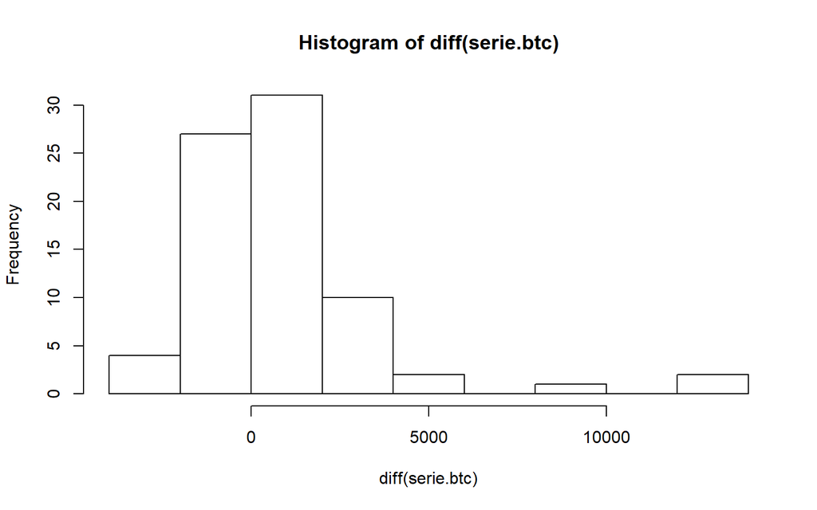

```r
h <- hist(diff(serie.btc), plot = T)
```

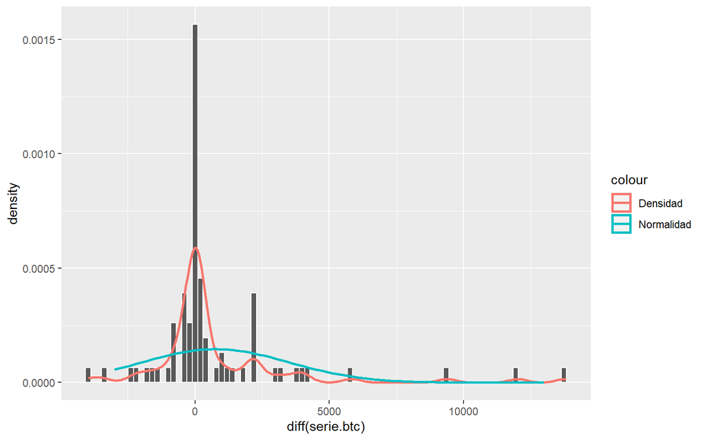

```r
x <- seq(min(h$mids, na.rm = T), max(h$mids, na.rm = T), length = length(serie.btc))
promedio   <- mean(diff(serie.btc), na.rm = T)
desviacion <- sd(diff(serie.btc), na.rm = T)
normalidad <- dnorm(x, promedio, desviacion)

ggplot() +
  geom_histogram(aes(x = diff(serie.btc), y = ..density..), bins = 90, color = "white") +
  geom_density(aes(x = diff(serie.btc), y = ..density.., color = "Densidad"), size = 1) +
  geom_line(aes(x = x, y = normalidad, color = "Normalidad"), size = 1)
```

### 3.3.4 Test qqnorm y test qqline

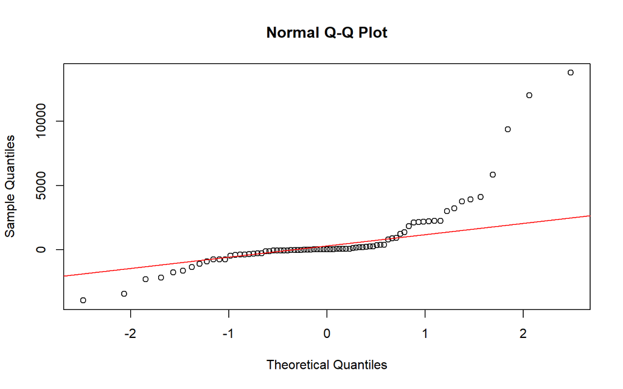

```r
qqnorm(diff(serie.btc))
qqline(diff(serie.btc), col = "red")
```

### 3.3.5 Test de normalidad

- Test chi-square de Pearson

```r
library(nortest)
pearson.test(serie.btc)$p.value
```

```
## [1] 0.000000000000000000000000005936373
```

- Test Lilliefors (Kolmogorov-Smirnov)

```r
library(nortest)
lillie.test(serie.btc)$p.value
```

```
## [1] 0.0000000000003168213
```

- Test de Cramer-von Mises

```r
library(nortest)
cvm.test(serie.btc)$p.value
```

```
## [1] 0.000000000737
```

Los tres tests nos dan un valor de p <= 0.05 (p-value <= 0.05), es decir por debajo del nivel de significancia de 0.05. Por lo que existe evidencia estadística para aceptar la hipotesis de que la muestra *NO* proviene de una distribución normal. Es decir, podemos afirmar que la “serie” no sigue una distribución normal.

Adicionalmente, los gráficos de normalidad no indican que los datos siguen la normal.

### 3.3.6 Descomposición de la serie

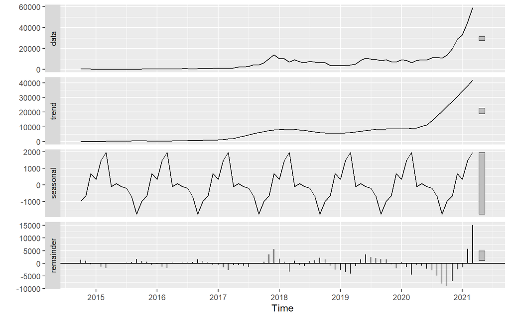

```r
library(forecast)

forecast::autoplot(stl(serie.btc, s.window = "periodic"))
```

### 3.3.7 Periodos más importantes

```r
library(dygraphs)
res <- spec.pgram(serie.btc, log = "no", plot = F)

#Ordena el espectro con respecto a la frecuencia en orden decreciente es decir de mayor a menor,
#el valor 1 no se toma en cuenta pues es toda la serie

max <- order(res$spec, res$freq, decreasing = TRUE)

max <- max[max != 1][1:3] # Ignoramos la posición 1 y tomamos las 3 primeras posiciones.
max
```

```
## [1] 2 4 5
```

```r
# Los periodos más importantes son
periodos <- valor_frecuencia/max
periodos
```

```
## [1] 6.0 3.0 2.4
```

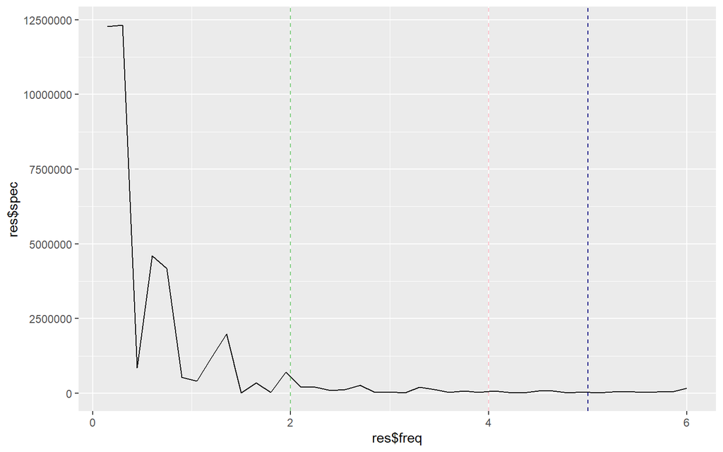

```r
ggplot() + geom_line(aes(x = res$freq, y = res$spec)) +
  geom_vline(xintercept = max[1], linetype = "dashed", color = "palegreen3") +
  geom_vline(xintercept = max[2], linetype = "dashed", color = "pink") +
  geom_vline(xintercept = max[3], linetype = "dashed", color = "navy")
```

```r
dygraphs::dygraph(res, 'Peridiograma', 'Frecuencia', 'Espectro', width = "100%") %>%
  dyEvent(max[1], color = "green") %>%
  dyEvent(max[2], color = "red") %>%
  dyEvent(max[3], color = "navy") %>%
  dyUnzoom() %>%
  dyCrosshair(direction = "vertical") %>%
  dyRangeSelector(height = 20, strokeColor = "black", fillColor = "black", )
```

[interactive chart not shown]

Determinamos que el periodo más importante es de 6.

### 3.3.8 Gráfico de la serie

```r
library(dygraphs)
library(xts)

aux <- xts::xts(serie.btc, order.by = as.Date(dataset.btc$Date))
dygraphs::dygraph(aux, main = "Precio del Bitcoin mensual desde el año 2014 al 2021", xlab = "Año", width = "100%") %>%
  dyAxis("y", label = "Precio($)") %>%
  dySeries("V1", label = "Precio($)", color = "#6FC0B3") %>%
  dyLegend(show = "follow") %>%
  dyUnzoom() %>%
  dyCrosshair(direction = "vertical") %>%
  #dyOptions(colors = RColorBrewer::brewer.pal(3, "Set2"))  %>%
  dyRangeSelector(height = 20, strokeColor = "black", fillColor = "black")
```

[interactive chart not shown]

## 3.4 **Modelado**

### 3.4.1 Serie en train y test

```r
serie.btc.train <- head(serie.btc, -valor_frecuencia)
serie.btc.test <- tail(serie.btc, valor_frecuencia)
```

## 3.5 **Construcción de modelos básico**

### 3.5.1 Método promedio

```r
metodo.promedio <- meanf(serie.btc.train, h = valor_frecuencia)
pred.promedio   <- forecast(metodo.promedio, h = valor_frecuencia)
```

### 3.5.2 Método Naive

```r
metodo.naive <- naive(serie.btc.train, h = valor_frecuencia)
pred.naive   <- forecast(metodo.naive, h = valor_frecuencia)
```

### 3.5.3 Método SNaive

```r
metodo.snaive <- snaive(serie.btc.train, h = valor_frecuencia)
pred.snaive   <- forecast(metodo.snaive, h = valor_frecuencia)
```

### 3.5.4 Método Drift

```r
metodo.drift<- rwf(serie.btc.train, h = valor_frecuencia, drift = T)
pred.drift  <- forecast(metodo.drift, h = valor_frecuencia)
```

### 3.5.5 Método STL

```r
metodo.stl <- stl(serie.btc.train, s.window = "periodic")
pred.stl   <- forecast(metodo.stl, h = valor_frecuencia)
```

## 3.6 **Evaluación de modelos básicos**

```r
library(xts)
library(forecast)
library(dygraphs)

errores <- tabla.errores(
  predicciones = list(pred.promedio$mean, pred.naive$mean, pred.snaive$mean, pred.drift$mean, pred.stl$mean),
  real = serie.btc.test,
  c("Promedio", "Naive", "S Naive", "Desvio", "Descomposición")
)

errores
```

```
##                      MSE     RMSE        PFA      PTFA
## Promedio       564024659 23749.20 0.00000000 0.0000000
## Naive          482657966 21969.48 0.00000000 0.0000000
## S Naive        443530938 21060.17 0.08333333 0.1837561
## Desvio         455443068 21341.11 0.00000000 0.0000000
## Descomposición 457006649 21377.71 0.00000000 0.0000000
```

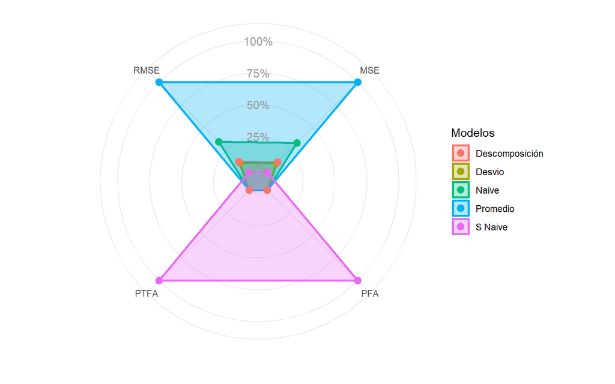

```r
grafico.errores(errores)
```

```r
predicciones <- ts.union(
  serie.btc.train, Original = serie.btc.test,
  'promedio' =       pred.promedio$mean,  'Naive' =          pred.naive$mean,
  'S Naive' =        pred.snaive$mean,
  'Desvio' =         pred.drift$mean,
  'Descomposición' = pred.stl$mean
)


predicciones <- xts(xts(predicciones, order.by = as.Date(dataset.btc$Date)))

dygraphs::dygraph(predicciones, main = "Predicción del precio del Bitcoin mensual con modelos básicos", width = "100%") %>%
  dyRangeSelector() %>%
  dyLegend(width = 800) %>% #show = "follow",
  dyUnzoom() %>%
  dyCrosshair(direction = "vertical") %>%
  dyRangeSelector(height = 20, strokeColor = "black", fillColor = "black")
```

[interactive chart not shown]

## 3.7 **Construcción de modelos avanzados**

### 3.7.1 Holt-Winters

```r
metodo.holtw <- stats::HoltWinters(serie.btc.train)
pred.holtw   <- forecast(metodo.holtw, h = valor_frecuencia) #n.ahead
```

#### 3.7.1.1 Calibración Holt-Winters

```r
library(stats)
library(forecast)

calibrar.HW(serie.btc.train, serie.btc.test)
```

```
## Holt-Winters exponential smoothing with trend and additive seasonal component.
##
## Call:
## HoltWinters(x = datos, alpha = 0.2, beta = 1, gamma = 1)
##
## Smoothing parameters:
##  alpha: 0.2
##  beta : 1
##  gamma: 1
##
## Coefficients:
##           [,1]
## a    3300.8682
## b    1154.1492
## s1  -2462.9954
## s2  -2148.6794
## s3  -2561.4734
## s4  -4378.4325
## s5  -4166.7595
## s6  -3210.0896
## s7    649.2896
## s8   1901.7932
## s9   4002.9117
## s10  7325.5160
## s11  6452.7897
## s12  3137.7763
```

```r
metodo.holtw.calibrado <- stats::HoltWinters(serie.btc.train, alpha = 0.2, beta = 1,  gamma = 1)
pred.holtw.calibrado   <-   forecast(metodo.holtw.calibrado, h = valor_frecuencia) #n.ahead
```

### 3.7.2 Redes Neuronales

```r
library(stats)
library(forecast)

metodo.nnet <- nnetar(serie.btc.train, size =30)
pred.nnet <- forecast(metodo.nnet, h = valor_frecuencia, PI = T)
```

### 3.7.3 Arima

#### 3.7.3.1 Autocorrelación Simple y Autocorrelación Parcial

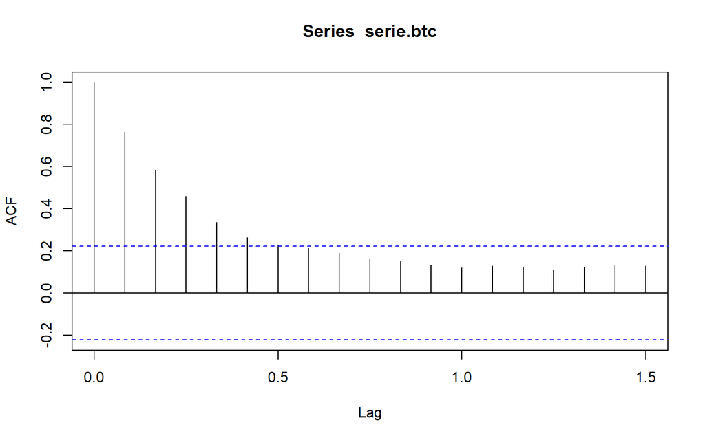

```r
acf(serie.btc)
```

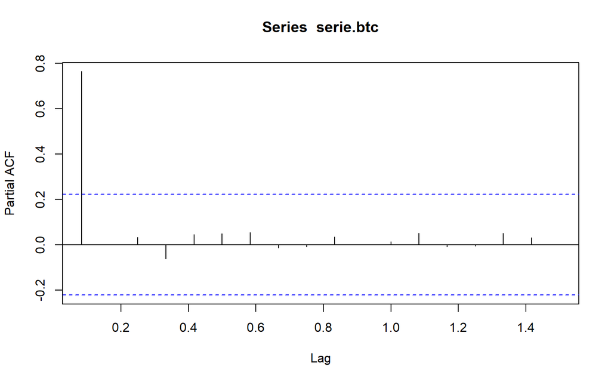

```r
pacf(serie.btc)
```

#### 3.7.3.2 Auto-Arima

```r
auto.arima(serie.btc.train)
```

```
## Series: serie.btc.train
## ARIMA(0,1,0)
##
## sigma^2 estimated as 1798843:  log likelihood=-560.32
## AIC=1122.63   AICc=1122.7   BIC=1124.81
```

```r
metodo.arima <- arima(serie.btc.train, order = c(0, 1, 0), list(order = c(0, 0, 0), period = 6)) #Periodo más importante
pred.arima   <- predict(metodo.arima, n.ahead = valor_frecuencia)
```

#### 3.7.3.3 Calibración periodo 6

```r
calibrar.arima(serie.btc.train, serie.btc.test, periodo = 6.0, 0:3, 0:2)
```

```
##
## Call:
## arima(x = datos, order = c(3, 3, 0), seasonal = list(order = c(0, 1, 0), period = 6))
##
## Coefficients:
##           ar1      ar2      ar3
##       -1.1406  -0.8328  -0.3503
## s.e.   0.1252   0.1674   0.1262
##
## sigma^2 estimated as 8684093:  log likelihood = -539,  aic = 1085.99
```

```r
metodo.arima.6 <- arima(serie.btc.train, order = c(3, 3, 0), seasonal = list(order = c(0, 1, 0), period = 6))

pred.arima.6 <- forecast(metodo.arima.6, h = valor_frecuencia)
pred.arima.6
```

```
##          Point Forecast       Lo 80     Hi 80       Lo 95     Hi 95
## Apr 2020       9054.698    5278.121  12831.27    3278.922  14830.47
## May 2020       9008.543    1035.144  16981.94   -3185.718  21202.80
## Jun 2020       9643.933   -4353.877  23641.74  -11763.869  31051.74
## Jul 2020      13891.825   -8496.428  36280.08  -20348.053  48131.70
## Aug 2020      15730.482  -17590.473  49051.44  -35229.522  66690.49
## Sep 2020      16100.922  -30500.465  62702.31  -55169.749  87371.59
## Oct 2020      21730.424  -43532.254  86993.10  -78080.229 121541.08
## Nov 2020      25230.744  -63015.677 113477.17 -109730.511 160192.00
## Dec 2020      29632.582  -86436.316 145701.48 -147879.480 207144.64
## Jan 2021      37992.260 -111374.605 187359.13 -190444.648 266429.17
## Feb 2021      44387.942 -144169.428 232945.31 -243985.670 332761.55
## Mar 2021      49651.947 -183964.356 283268.25 -307633.357 406937.25
```

#### 3.7.3.4 Calibración periodo 3

```r
calibrar.arima(serie.btc.train, serie.btc.test, periodo = 3.0, 0:3, 0:2)
```

```
##
## Call:
## arima(x = datos, order = c(3, 3, 1), seasonal = list(order = c(0, 2, 0), period = 3))
##
## Coefficients:
##           ar1      ar2      ar3      ma1
##       -0.3769  -0.0906  -0.5745  -0.9989
## s.e.   0.1047   0.1157   0.1027   0.0466
##
## sigma^2 estimated as 10614033:  log likelihood = -546.84,  aic = 1103.68
```

```r
metodo.arima.3 <- arima(serie.btc.train, order = c(3, 3, 1), seasonal = list(order = c(0, 2, 0), period = 3))

pred.arima.3 <- forecast(metodo.arima.3, h = valor_frecuencia)
pred.arima.3
```

```
##          Point Forecast       Lo 80     Hi 80       Lo 95     Hi 95
## Apr 2020      11530.697    7320.467  15740.93    5091.705  17969.69
## May 2020      10717.859    2628.276  18807.44   -1654.090  23089.81
## Jun 2020       9188.318   -3570.841  21947.48  -10325.132  28701.77
## Jul 2020      16071.310   -6765.423  38908.04  -18854.459  50997.08
## Aug 2020      16609.736  -18579.749  51799.22  -37207.937  70427.41
## Sep 2020      14566.533  -34773.231  63906.30  -60892.125  90025.19
## Oct 2020      24884.963  -46693.548  96463.47  -84584.923 134354.85
## Nov 2020      26142.178  -71701.566 123985.92 -123496.916 175781.27
## Dec 2020      25039.578 -102655.558 152734.71 -170253.280 220332.44
## Jan 2021      38076.717 -129993.349 206146.78 -218964.268 295117.70
## Feb 2021      41284.953 -173714.136 256284.04 -287527.779 370097.68
## Mar 2021      40630.227 -226855.310 308115.76 -368453.599 449714.05
```

#### 3.7.3.5 Calibración periodo 2.4

```r
calibrar.arima(serie.btc.train, serie.btc.test, periodo = 2.4, 0:3, 0:2)
```

```
##
## Call:
## arima(x = datos, order = c(3, 1, 3), seasonal = list(order = c(0, 1, 1), period = 2.4))
##
## Coefficients:
##          ar1     ar2      ar3      ma1      ma2     ma3     sma1
##       0.6868  0.9332  -0.7400  -0.7639  -0.9543  0.7182  -1.0000
## s.e.  0.2973     NaN   0.2467   0.4261   0.1188  0.4079   0.0929
##
## sigma^2 estimated as 1567151:  log likelihood = -544.56,  aic = 1105.11
```

```r
metodo.arima.2.4 <- arima(serie.btc.train, order = c(3, 1, 3), seasonal = list(order = c(0, 1, 1), period = 2.4))

pred.arima.2.4<- forecast(metodo.arima.2.4, h = valor_frecuencia)
pred.arima.2.4
```

```
##          Point Forecast    Lo 80     Hi 80    Lo 95     Hi 95
## Apr 2020       6975.449 5319.038  8631.861 4442.186  9508.712
## May 2020       6977.291 4662.302  9292.280 3436.821 10517.761
## Jun 2020       7685.373 4875.376 10495.371 3387.853 11982.894
## Jul 2020       7790.142 4638.657 10941.627 2970.362 12609.923
## Aug 2020       8543.057 5125.748 11960.367 3316.734 13769.381
## Sep 2020       8647.919 5055.553 12240.284 3153.870 14141.968
## Oct 2020       9366.568 5640.660 13092.476 3668.283 15064.852
## Nov 2020       9414.805 5608.727 13220.884 3593.910 15235.700
## Dec 2020      10062.522 6195.426 13929.618 4148.309 15976.735
## Jan 2021      10034.562 6135.810 13933.314 4071.936 15997.189
## Feb 2021      10605.659 6681.096 14530.221 4603.558 16607.759
## Mar 2021      10506.464 6571.865 14441.063 4489.015 16523.914
```

## 3.8 **Evaluación de modelos avanzados**

```r
library(xts)
library(dygraphs)

errores <- tabla.errores(
  predicciones = list(pred.holtw$mean, pred.holtw.calibrado$mean, pred.nnet$mean, pred.arima$pred, pred.arima.6$mean, pred.arima.3$mean, pred.arima.2.4$mean),
  real = serie.btc.test,
  c("Holt-Winters", "HW Fuerza Bruta", "Redes Neuronales", "Auto.Arima", "Arima 6", "Arima 3", "Arima 2.4")

)

errores
```

```
##                        MSE      RMSE  PFA      PTFA
## Holt-Winters     476124038 21820.267 0.00 0.0000000
## HW Fuerza Bruta  209198995 14463.713 0.00 0.0000000
## Redes Neuronales 406401752 20159.409 0.00 0.0000000
## Auto.Arima       482657966 21969.478 0.00 0.0000000
## Arima 6           21423567  4628.560 0.75 0.2168188
## Arima 3           52195781  7224.665 0.75 0.3152574
## Arima 2.4        382447242 19556.258 0.00 0.0000000
```

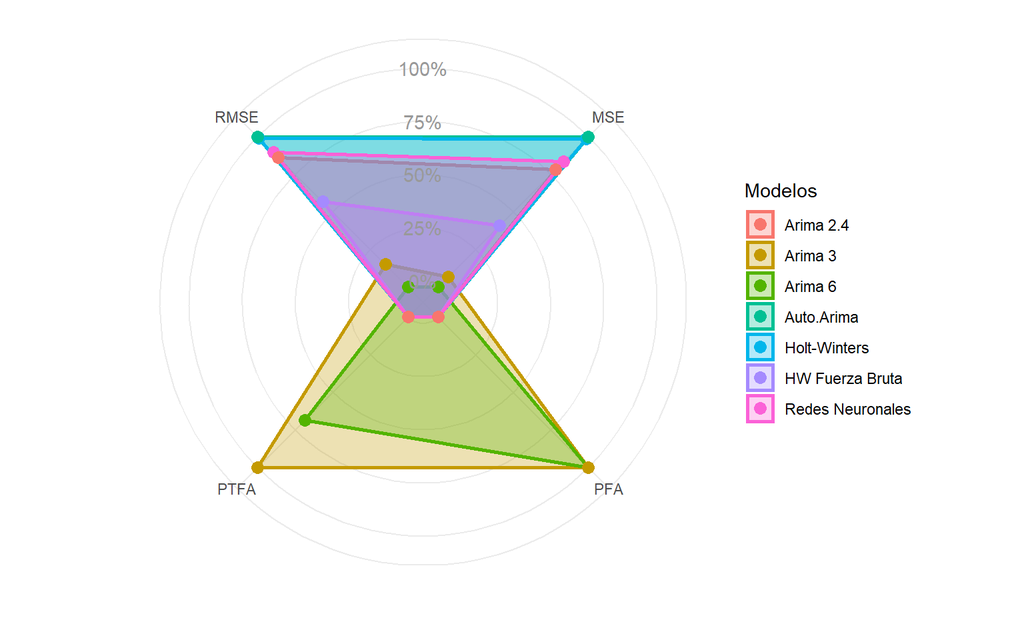

```r
grafico.errores(errores)
```

```r
# Primero unimos en una sola tabla la serie original con las predicciones.
serie.pred <- ts.union(serie.btc.train,
                       Original = serie.btc.test,
                       'Holt-Winters' = pred.holtw$mean,
                       'HW Fuerza Bruta' = pred.holtw.calibrado$mean,
                       'Redes Neuronales' = pred.nnet$mean,
                       'Auto.Arima' = pred.arima$pred,
                       'Arima 6' = pred.arima.6$mean,
                       'Arima 3' = pred.arima.3$mean,
                       'Arima 2.4' = pred.arima.2.4$mean)

serie.pred <- xts(xts(serie.pred, order.by = as.Date(dataset.btc$Date)))

dygraphs::dygraph(serie.pred, main = "Predicción del precio del Bitcoin mensual con modelos avanzados", width = "100%") %>%
  dyRangeSelector() %>%
  dyLegend( width = 800) %>% #show = "follow",
  dyUnzoom() %>%
  dyCrosshair(direction = "vertical") %>%
  dyRangeSelector(height = 20, strokeColor = "black", fillColor = "black")
```

[interactive chart not shown]

## 3.9 **Selección del mejor modelo**

Seleccionamos el mejor modelo y realizamos una nueva predicción utilizando toda la serie de tiempo. En este caso utilizaremos Arima calibrado con el periodo 6.

```r
library(dygraphs)

metodo.arima.6 <- arima(serie.btc, order = c(3, 3, 0), seasonal = list(order = c(0, 1, 0), period = 6))

pred.arima.6 <- forecast(metodo.arima.6, h = 6, level = c(95))
pred.arima.6
```

```
##          Point Forecast     Lo 95     Hi 95
## Apr 2021       75965.58  70028.89  81902.26
## May 2021       98687.16  86553.16 110821.15
## Jun 2021      130053.66 109247.16 150860.15
## Jul 2021      156670.01 123512.89 189827.13
## Aug 2021      193567.57 144312.94 242822.20
## Sep 2021      235861.02 167343.36 304378.68
```

```r
prediccion <- ts.union(
  pred.arima.6 = pred.arima.6$mean, LimInf = pred.arima.6$lower, LimSup = pred.arima.6$upper
)

serie.final <- ts.union(serie.btc, prediccion)
head(serie.final)
```

```
##          serie.btc prediccion.pred.arima.6 prediccion.LimInf prediccion.LimSup
## Oct 2014   338.321                      NA                NA                NA
## Nov 2014   378.047                      NA                NA                NA
## Dec 2014   320.193                      NA                NA                NA
## Jan 2015   217.464                      NA                NA                NA
## Feb 2015   254.263                      NA                NA                NA
## Mar 2015   244.224                      NA                NA                NA
```

```r
fecha.fin <- dataset.btc$Date[nrow(dataset.btc)]
fechas <- fecha.fin + months(1:6)
total.fechas <- c(dataset.btc$Date, fechas)

serie.final <- xts(xts(serie.final, order.by = total.fechas))

dygraphs::dygraph(serie.final, main = "Predicción Bitcoin para los próximos 6 meses", xlab = "Año", width = "100%") %>%
  dyAxis("y", label = "Precio($)") %>%
  dySeries(c("prediccion.LimInf", "prediccion.pred.arima.6", "prediccion.LimSup"), label = "Predicción") %>%
  dyLegend(show = "follow") %>%
  dyUnzoom() %>%
  dyCrosshair(direction = "vertical") %>%
  dyRangeSelector(height = 20, strokeColor = "black", fillColor = "black")
```

[interactive chart not shown]

# 4 **Ethereum (ETH)**

## 4.1 **Descripción de los datos**

### 4.1.1 Carga de datos

```r
library(DT)
Sys.setlocale("LC_TIME", "Spanish")
```

```
## [1] "Spanish_Spain.1252"
```

```r
dataset.eth <- read.csv(file = "datos/ETH-USD_M.csv", head = TRUE, sep=",")
DT::datatable(dataset.eth)
```

|  | Date | Open | High | Low | Close | Adj.Close | Volume |
| --- | --- | --- | --- | --- | --- | --- | --- |
| 1 | 2015-09-01 | 1.35348 | 1.39274 | 0.557062 | 0.738644 | 0.738644 | 19920655 |
| 2 | 2015-10-01 | 0.734307 | 1.34505 | 0.420897 | 0.916627 | 0.916627 | 19815600 |
| 3 | 2015-11-01 | 0.920847 | 1.10642 | 0.725665 | 0.873119 | 0.873119 | 25989045 |
| 4 | 2015-12-01 | 0.878316 | 1.04537 | 0.770488 | 0.933542 | 0.933542 | 14436832 |
| 5 | 2016-01-01 | 0.933712 | 2.83699 | 0.929835 | 2.30604 | 2.30604 | 99427369 |
| 6 | 2016-02-01 | 2.31969 | 6.64741 | 2.11631 | 6.33699 | 6.33699 | 350388940 |
| 7 | 2016-03-01 | 6.31931 | 15.2571 | 6.30885 | 11.4035 | 11.4035 | 911491280 |
| 8 | 2016-04-01 | 11.4006 | 11.8504 | 7.05898 | 8.81398 | 8.81398 | 503439580 |
| 9 | 2016-05-01 | 8.77508 | 15.0482 | 8.43236 | 14.0773 | 14.0773 | 866285490 |
| 10 | 2016-06-01 | 14.1098 | 21.522699 | 9.96364 | 12.4615 | 12.4615 | 1179208426 |

[output cut: 57 more lines]

```r
valor_frecuencia = 12
```

- Date: Columna que muestra la fecha en formato yyyy-mm-dd
- Open: Precio de apertura
- High: Precio más alto
- Low: Precio más bajo
- Close: Precio de clausura
- Adj Close: Precio de clausura con ajustes
- Volume: Volumen de monedas intercambiadas

## 4.2 **Exploración de los datos**

### 4.2.1 Exploración de los datos

```r
summary(dataset.eth)
```

```
##          Date         Open                High               Low
##  2015-09-01: 1   Min.   :   0.7343   Min.   :   1.045   Min.   :   0.4209
##  2015-10-01: 1   1st Qu.:  13.6565   1st Qu.:  18.791   1st Qu.:  10.9022
##  2015-11-01: 1   Median : 183.8037   Median : 236.965   Median : 157.1303
##  2015-12-01: 1   Mean   : 263.0891   Mean   : 356.844   Mean   : 214.9974
##  2016-01-01: 1   3rd Qu.: 352.9016   3rd Qu.: 427.799   3rd Qu.: 279.3735
##  2016-02-01: 1   Max.   :1417.1511   Max.   :2036.286   Max.   :1416.4161
##  (Other)   :61
##      Close             Adj.Close             Volume
##  Min.   :   0.7386   Min.   :   0.7386   Min.   :     14436832
##  1st Qu.:  14.9473   1st Qu.:  14.9473   1st Qu.:   1045349853
##  Median : 197.3810   Median : 197.3810   Median :  59375107547
##  Mean   : 291.6423   Mean   : 291.6423   Mean   : 174677055303
##  3rd Qu.: 371.5322   3rd Qu.: 371.5322   3rd Qu.: 251950118455
##  Max.   :1918.3621   Max.   :1918.3621   Max.   :1186797483410
##
```

```r
str(dataset.eth)
```

```
## 'data.frame':    67 obs. of  7 variables:
##  $ Date     : Factor w/ 67 levels "2015-09-01","2015-10-01",..: 1 2 3 4 5 6 7 8 9 10 ...
##  $ Open     : num  1.353 0.734 0.921 0.878 0.934 ...
##  $ High     : num  1.39 1.35 1.11 1.05 2.84 ...
##  $ Low      : num  0.557 0.421 0.726 0.77 0.93 ...
##  $ Close    : num  0.739 0.917 0.873 0.934 2.306 ...
##  $ Adj.Close: num  0.739 0.917 0.873 0.934 2.306 ...
##  $ Volume   : num  19920655 19815600 25989045 14436832 99427369 ...
```

## 4.3 **Preparación de los datos**

### 4.3.1 Formateo de los datos

```r
library(lubridate)

dataset.eth[dataset.eth == 'null'] <- NA
dataset.eth$Date      <- ymd(dataset.eth$Date)
dataset.eth$Open      <- as.numeric(as.character(dataset.eth$Open))
dataset.eth$High      <- as.numeric(as.character(dataset.eth$High))
dataset.eth$Low       <- as.numeric(as.character(dataset.eth$Low))
dataset.eth$Close     <- as.numeric(as.character(dataset.eth$Close))
dataset.eth$Adj.Close <- as.numeric(as.character(dataset.eth$Adj.Close))
dataset.eth$Volume    <- as.numeric(as.character(dataset.eth$Volume))
DT::datatable(dataset.eth)
```

|  | Date | Open | High | Low | Close | Adj.Close | Volume |
| --- | --- | --- | --- | --- | --- | --- | --- |
| 1 | 2015-09-01 | 1.35348 | 1.39274 | 0.557062 | 0.738644 | 0.738644 | 19920655 |
| 2 | 2015-10-01 | 0.734307 | 1.34505 | 0.420897 | 0.916627 | 0.916627 | 19815600 |
| 3 | 2015-11-01 | 0.920847 | 1.10642 | 0.725665 | 0.873119 | 0.873119 | 25989045 |
| 4 | 2015-12-01 | 0.878316 | 1.04537 | 0.770488 | 0.933542 | 0.933542 | 14436832 |
| 5 | 2016-01-01 | 0.933712 | 2.83699 | 0.929835 | 2.30604 | 2.30604 | 99427369 |
| 6 | 2016-02-01 | 2.31969 | 6.64741 | 2.11631 | 6.33699 | 6.33699 | 350388940 |
| 7 | 2016-03-01 | 6.31931 | 15.2571 | 6.30885 | 11.4035 | 11.4035 | 911491280 |
| 8 | 2016-04-01 | 11.4006 | 11.8504 | 7.05898 | 8.81398 | 8.81398 | 503439580 |
| 9 | 2016-05-01 | 8.77508 | 15.0482 | 8.43236 | 14.0773 | 14.0773 | 866285490 |
| 10 | 2016-06-01 | 14.1098 | 21.522699 | 9.96364 | 12.4615 | 12.4615 | 1179208426 |

[output cut: 57 more lines]

### 4.3.2 Correción de fechas e imputación

```r
library(dplyr)

fecha.inicio <- dataset.eth$Date[1]
fecha.final  <- dataset.eth$Date[nrow(dataset.eth)]

total.fechas <- seq(fecha.inicio, fecha.final, by = "month")

faltan.fechas <- total.fechas[!total.fechas %in% dataset.eth$Date]
faltan.fechas
```

```
## Date of length 0
```

```r
dataset.eth <- dplyr::union_all(dataset.eth, data.frame(Date = faltan.fechas))
dataset.eth <- dataset.eth[order(dataset.eth$Date), ]

dataset.eth$Open[is.na(dataset.eth$Open)] <- mean(dataset.eth$Open, na.rm = T)
dataset.eth$High[is.na(dataset.eth$High)] <- mean(dataset.eth$High, na.rm = T)
dataset.eth$Low[is.na(dataset.eth$Low)] <- mean(dataset.eth$Low, na.rm = T)
dataset.eth$Close[is.na(dataset.eth$Close)] <- mean(dataset.eth$Close, na.rm = T)
dataset.eth$Adj.Close[is.na(dataset.eth$Adj.Close)] <- mean(dataset.eth$Adj.Close, na.rm = T)
dataset.eth$Volume[is.na(dataset.eth$Volume)] <- mean(dataset.eth$Volume, na.rm = T)

summary(dataset.eth)
```

```
##       Date                 Open                High
##  Min.   :2015-09-01   Min.   :   0.7343   Min.   :   1.045
##  1st Qu.:2017-01-16   1st Qu.:  13.6565   1st Qu.:  18.791
##  Median :2018-06-01   Median : 183.8037   Median : 236.965
##  Mean   :2018-06-01   Mean   : 263.0891   Mean   : 356.844
##  3rd Qu.:2019-10-16   3rd Qu.: 352.9016   3rd Qu.: 427.799
##  Max.   :2021-03-01   Max.   :1417.1511   Max.   :2036.286
##       Low                Close             Adj.Close
##  Min.   :   0.4209   Min.   :   0.7386   Min.   :   0.7386
##  1st Qu.:  10.9022   1st Qu.:  14.9473   1st Qu.:  14.9473
##  Median : 157.1303   Median : 197.3810   Median : 197.3810
##  Mean   : 214.9974   Mean   : 291.6423   Mean   : 291.6423
##  3rd Qu.: 279.3735   3rd Qu.: 371.5322   3rd Qu.: 371.5322
##  Max.   :1416.4161   Max.   :1918.3621   Max.   :1918.3621
##      Volume
##  Min.   :     14436832
##  1st Qu.:   1045349853
##  Median :  59375107547
##  Mean   : 174677055303
##  3rd Qu.: 251950118455
##  Max.   :1186797483410
```

### 4.3.3 Normalidad de la serie

```r
library(ggplot2)
library(tseries)

dia.inicio <- which(dataset.eth$Date == "2015-09-01")
dia.inicio
```

```
## [1] 1
```

```r
serie.eth <- ts(dataset.eth$Close, frequency = valor_frecuencia, start = c(2015, 9))
#Patrón Estacional Anual. Frecuencia 12. Los datos vienen mensuales

serie.eth
```

```
##              Jan         Feb         Mar         Apr         May         Jun
## 2015
## 2016    2.306040    6.336990   11.403500    8.813980   14.077300   12.461500
## 2017   10.727500   15.817200   50.037300   79.021202  230.669006  294.915985
## 2018 1118.310059  855.198975  396.457001  669.924011  577.645020  455.179993
## 2019  107.061012  136.746246  141.514099  162.166031  268.113556  290.695984
## 2020  180.160172  219.848511  133.593567  207.602051  230.975708  226.315002
## 2021 1314.986206 1416.048950 1918.362061
##              Jul         Aug         Sep         Oct         Nov         Dec
## 2015                            0.738644    0.916627    0.873119    0.933542
## 2016   11.875900   11.672400   13.224800   10.998200    8.587540    7.969100
## 2017  203.871002  383.041992  301.464996  305.878998  447.114014  756.732971
## 2018  433.867004  283.003998  232.848007  197.380997  113.171417  133.368256
## 2019  218.654144  172.469788  179.872208  183.966919  152.539688  129.610855
## 2020  345.554657  435.079742  360.022369  386.590332  614.842529  737.803406
## 2021
```

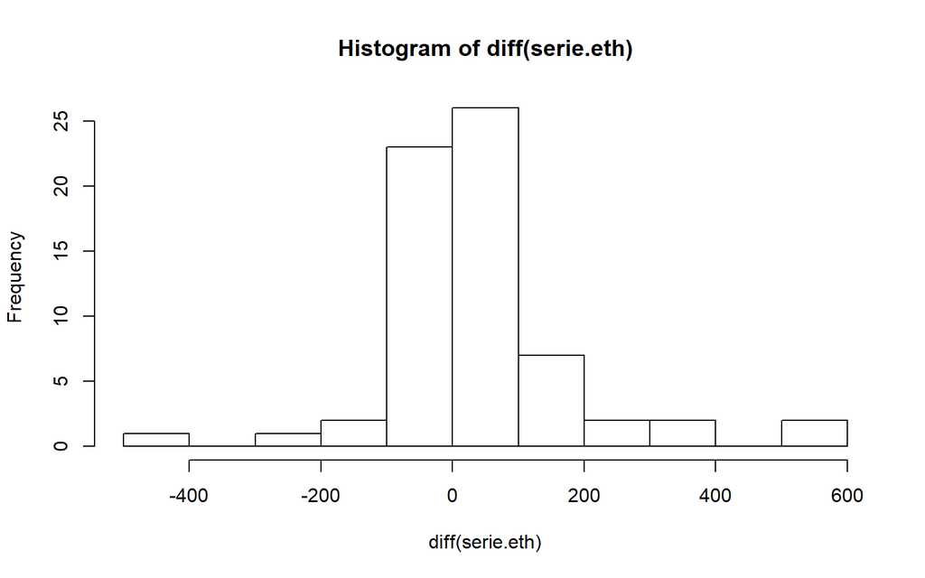

```r
h <- hist(diff(serie.eth), plot = T)
```

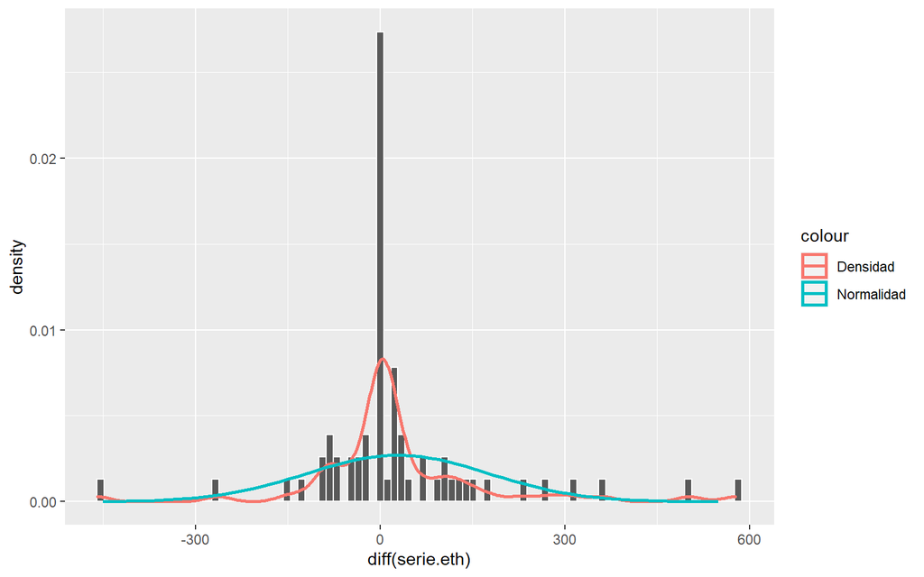

```r
x <- seq(min(h$mids, na.rm = T), max(h$mids, na.rm = T), length = length(serie.eth))
promedio   <- mean(diff(serie.eth), na.rm = T)
desviacion <- sd(diff(serie.eth), na.rm = T)
normalidad <- dnorm(x, promedio, desviacion)

ggplot() +
  geom_histogram(aes(x = diff(serie.eth), y = ..density..), bins = 90, color = "white") +
  geom_density(aes(x = diff(serie.eth), y = ..density.., color = "Densidad"), size = 1) +
  geom_line(aes(x = x, y = normalidad, color = "Normalidad"), size = 1)
```

### 4.3.4 Test qqnorm y test qqline

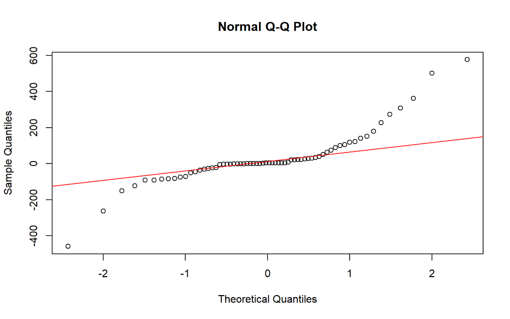

```r
qqnorm(diff(serie.eth))
qqline(diff(serie.eth), col = "red")
```

### 4.3.5 Test de normalidad

- Test chi-square de Pearson

```r
library(nortest)
pearson.test(serie.eth)$p.value
```

```
## [1] 0.000000003836976
```

- Test Lilliefors (Kolmogorov-Smirnov)

```r
library(nortest)
lillie.test(serie.eth)$p.value
```

```
## [1] 0.00000006252807
```

- Test de Cramer-von Mises

```r
library(nortest)
cvm.test(serie.eth)$p.value
```

```
## [1] 0.000000004806097
```

Los tres tests nos dan un valor de p <= 0.05 (p-value <= 0.05), es decir por debajo del nivel de significancia de 0.05. Por lo que existe evidencia estadística para aceptar la hipotesis de que la muestra *NO* proviene de una distribución normal. Es decir, podemos afirmar que la “serie” no sigue una distribución normal.

### 4.3.6 Descomposición de la serie

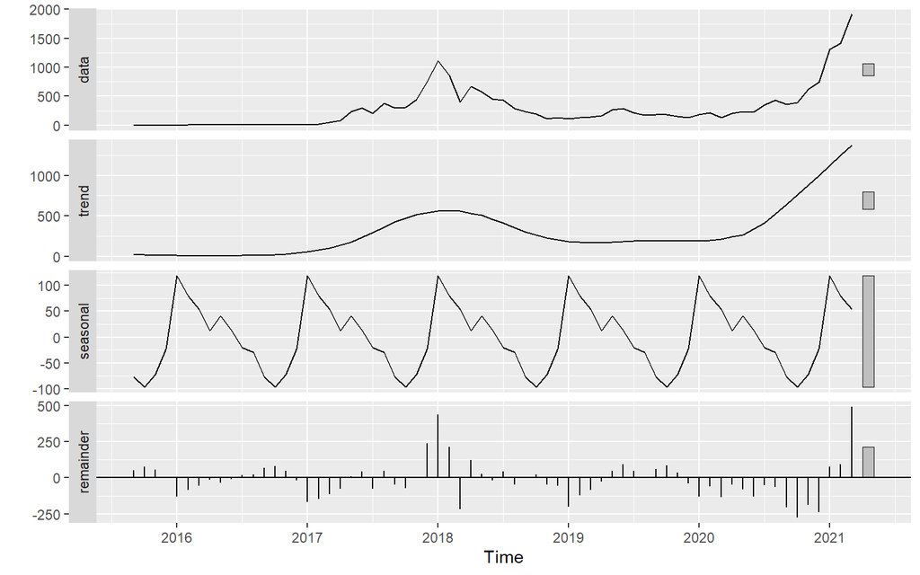

```r
library(forecast)

forecast::autoplot(stl(serie.eth, s.window = "periodic"))
```

### 4.3.7 Periodos más importantes

```r
library(dygraphs)
res <- spec.pgram(serie.eth, log = "no", plot = F)

#Ordena el espectro con respecto a la frecuencia en orden decreciente es decir de mayor a menor,
#el valor 1 no se toma en cuenta pues es toda la serie

max <- order(res$spec, res$freq, decreasing = TRUE)

max <- max[max != 1][1:3] # Ignoramos la posición 1 y tomamos las 3 primeras posiciones.
max
```

```
## [1] 2 4 3
```

```r
# Los periodos más importantes son
periodos <- valor_frecuencia/max
periodos
```

```
## [1] 6 3 4
```

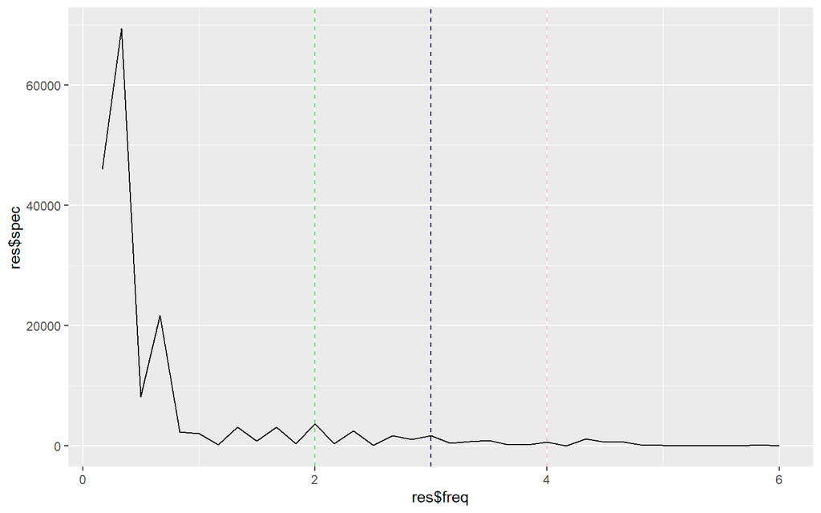

```r
ggplot() + geom_line(aes(x = res$freq, y = res$spec)) +
  geom_vline(xintercept = max[1], linetype = "dashed", color = "palegreen3") +
  geom_vline(xintercept = max[2], linetype = "dashed", color = "pink") +
  geom_vline(xintercept = max[3], linetype = "dashed", color = "navy")
```

```r
dygraphs::dygraph(res, 'Peridiograma', 'Frecuencia', 'Espectro', width = "100%") %>%
  dyEvent(max[1], color = "green") %>%
  dyEvent(max[2], color = "red") %>%
  dyEvent(max[3], color = "navy") %>%
  dyUnzoom() %>%
  dyCrosshair(direction = "vertical") %>%
  dyRangeSelector(height = 20, strokeColor = "black", fillColor = "black", )
```

[interactive chart not shown]

Determinamos que el periodo más importante es de 6.

### 4.3.8 Gráfico de la serie

```r
library(dygraphs)
library(xts)

aux <- xts::xts(serie.eth, order.by = as.Date(dataset.eth$Date))
dygraphs::dygraph(aux, main = "Precio del Ethereum mensual desde el año 2015 al 2021", xlab = "Año", width = "100%") %>%
  dyAxis("y", label = "Precio($)") %>%
  dySeries("V1", label = "Precio($)", color = "#6FC0B3") %>%
  dyLegend(show = "follow") %>%
  dyUnzoom() %>%
  dyCrosshair(direction = "vertical") %>%
  #dyOptions(colors = RColorBrewer::brewer.pal(3, "Set2"))  %>%
  dyRangeSelector(height = 20, strokeColor = "black", fillColor = "black")
```

[interactive chart not shown]

## 4.4 **Modelado**

### 4.4.1 Serie en train y test

```r
serie.eth.train <- head(serie.eth, -valor_frecuencia)
serie.eth.test <- tail(serie.eth, valor_frecuencia)
```

## 4.5 **Construcción de modelos básicos**

### 4.5.1 Método promedio

```r
metodo.promedio <- meanf(serie.eth.train, h = valor_frecuencia)
pred.promedio   <- forecast(metodo.promedio, h = valor_frecuencia)
```

### 4.5.2 Método Naive

```r
metodo.naive <- naive(serie.eth.train, h = valor_frecuencia)
pred.naive   <- forecast(metodo.naive, h = valor_frecuencia)
```

### 4.5.3 Método SNaive

```r
metodo.snaive <- snaive(serie.eth.train, h = valor_frecuencia)
pred.snaive   <- forecast(metodo.snaive, h = valor_frecuencia)
```

### 4.5.4 Método Drift

```r
metodo.drift<- rwf(serie.eth.train, h = valor_frecuencia, drift = T)
pred.drift  <- forecast(metodo.drift, h = valor_frecuencia)
```

### 4.5.5 Método STL

```r
metodo.stl <- stl(serie.eth.train, s.window = "periodic")
pred.stl   <- forecast(metodo.stl, h = valor_frecuencia)
```

## 4.6 **Evaluación de modelos básicos**

```r
library(xts)
library(forecast)
library(dygraphs)

errores <- tabla.errores(
  predicciones = list(pred.promedio$mean, pred.naive$mean, pred.snaive$mean, pred.drift$mean, pred.stl$mean),
  real = serie.eth.test,
  c("Promedio", "Naive", "S Naive", "Desvio", "Descomposición")
)

errores
```

```
##                     MSE     RMSE       PFA       PTFA
## Promedio       516854.2 718.9257 0.0000000 0.00000000
## Naive          591425.5 769.0419 0.0000000 0.00000000
## S Naive        554492.7 744.6427 0.1666667 0.22200064
## Desvio         566060.8 752.3701 0.0000000 0.00000000
## Descomposición 530387.0 728.2767 0.2500000 0.04740452
```

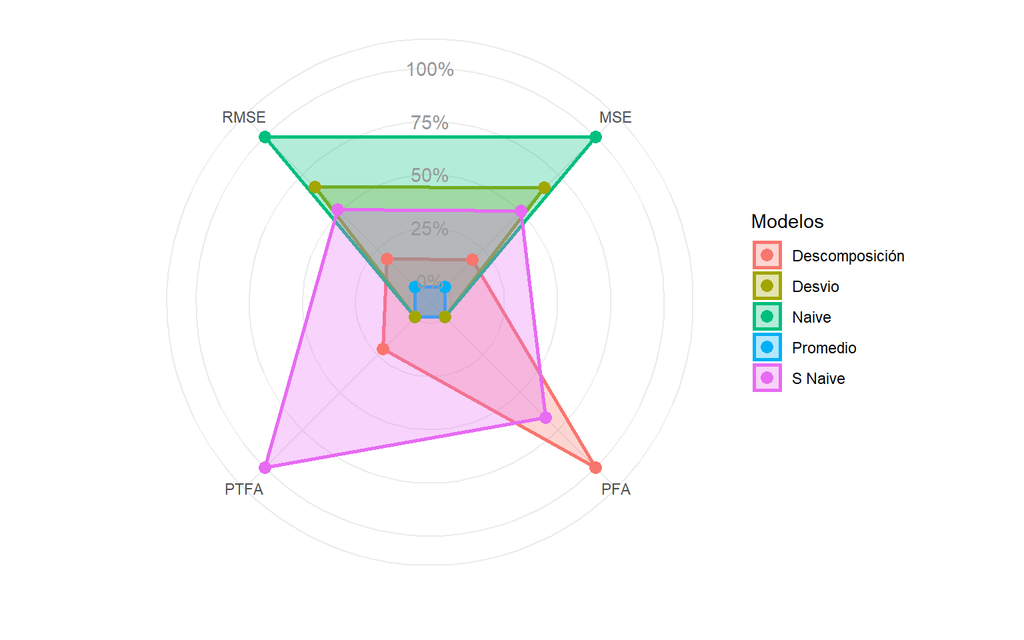

```r
grafico.errores(errores)
```

```r
predicciones <- ts.union(
  serie.eth.train, Original = serie.eth.test,
  'promedio' =       pred.promedio$mean,
  'Naive' =          pred.naive$mean,
  'S Naive' =        pred.snaive$mean,
  'Desvio' =         pred.drift$mean,
  'Descomposición' = pred.stl$mean
)


predicciones <- xts(xts(predicciones, order.by = as.Date(dataset.eth$Date)))

dygraphs::dygraph(predicciones, main = "Predicción del precio del Ethereum mensual con modelos básicos", width = "100%") %>%
  dyRangeSelector() %>%
  dyLegend(width = 800) %>% #show = "follow",
  dyUnzoom() %>%
  dyCrosshair(direction = "vertical") %>%
  dyRangeSelector(height = 20, strokeColor = "black", fillColor = "black")
```

[interactive chart not shown]

A pesar de varios modelos básicos poseen un RMSE y MSE bajos ninguno de los modelos aplicados anterionmente realmente el precio del Ethereum utilizanto 12 meses como prueba.

## 4.7 **Construcción de modelos avanzados**

### 4.7.1 Holt-Winters

```r
metodo.holtw <- stats::HoltWinters(serie.eth.train)
pred.holtw   <- forecast(metodo.holtw, h = valor_frecuencia) #n.ahead
```

#### 4.7.1.1 Calibración Holt-Winters

```r
library(stats)
library(forecast)

calibrar.HW(serie.eth.train, serie.eth.test)
```

```
## Holt-Winters exponential smoothing with trend and additive seasonal component.
##
## Call:
## HoltWinters(x = datos, alpha = 0.3, beta = 0.8, gamma = 0.8)
##
## Smoothing parameters:
##  alpha: 0.3
##  beta : 0.8
##  gamma: 0.8
##
## Coefficients:
##           [,1]
## a     58.83973
## b     98.81897
## s1  -183.48562
## s2  -178.61759
## s3  -182.97010
## s4  -174.16557
## s5  -101.38107
## s6    24.84152
## s7   123.10191
## s8   152.09759
## s9   194.86489
## s10  264.53192
## s11  241.77933
## s12   34.34222
```

```r
metodo.holtw.calibrado <- stats::HoltWinters(serie.eth.train, alpha = 0.3, beta = 0.8,  gamma = 0.8)
pred.holtw.calibrado   <-   forecast(metodo.holtw.calibrado, h = valor_frecuencia) #n.ahead
```

### 4.7.2 Redes Neuronales

```r
library(stats)
library(forecast)

metodo.nnet <- nnetar(serie.eth.train, size = 30)
pred.nnet <- forecast(metodo.nnet, h = valor_frecuencia, PI = T)
```

### 4.7.3 Arima

#### 4.7.3.1 Autocorrelación Simple y Autocorrelación Parcial

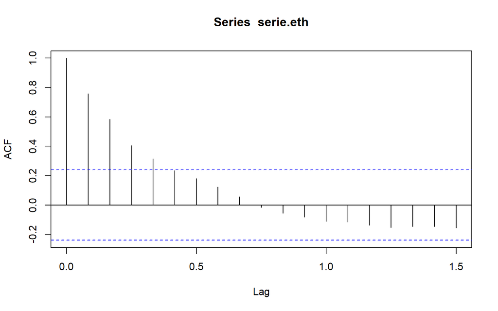

```r
acf(serie.eth)
```

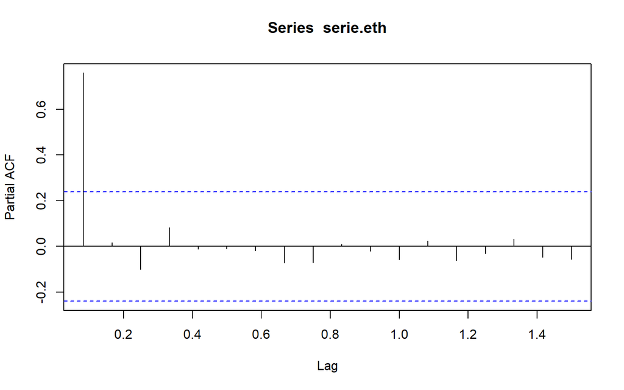

```r
pacf(serie.eth)
```

#### 4.7.3.2 Auto-Arima

```r
auto.arima(serie.eth.train)
```

```
## Series: serie.eth.train
## ARIMA(0,1,0)
##
## sigma^2 estimated as 14251:  log likelihood=-334.87
## AIC=671.73   AICc=671.81   BIC=673.72
```

```r
metodo.arima <- arima(serie.eth.train, order = c(0, 1, 0), list(order = c(0, 0, 0), period = 6)) #Periodo más importante
pred.arima   <- predict(metodo.arima, n.ahead = valor_frecuencia)
```

#### 4.7.3.3 Calibración periodo 6

```r
calibrar.arima(serie.eth.train, serie.eth.test, periodo = 6, 0:3, 0:2)
```

```
##
## Call:
## arima(x = datos, order = c(1, 3, 3), seasonal = list(order = c(2, 2, 2), period = 6))
##
## Coefficients:
##           ar1      ma1      ma2     ma3     sar1     sar2     sma1    sma2
##       -0.4420  -1.1297  -0.6472  0.8048  -0.3309  -0.2132  -1.0640  0.0899
## s.e.   0.2069   0.3312   0.4742  0.2769   5.0865   0.7294   6.2023  6.5318
##
## sigma^2 estimated as 26235:  log likelihood = -275.58,  aic = 569.15
```

```r
metodo.arima.6 <- arima(serie.eth.train, order = c(1, 3, 3), seasonal = list(order = c(2, 2, 2), period = 6))

pred.arima.6 <- forecast(metodo.arima.6, h = valor_frecuencia)
pred.arima.6
```

```
##          Point Forecast      Lo 80     Hi 80      Lo 95     Hi 95
## Apr 2020       164.3239  -60.81316  389.4610  -179.9935  508.6414
## May 2020       211.4740 -188.60961  611.5575  -400.4011  823.3490
## Jun 2020       268.2151 -246.19858  782.6288  -518.5127 1054.9430
## Jul 2020       363.2080 -271.25296  997.6690  -607.1163 1333.5324
## Aug 2020       473.4089 -277.56956 1224.3873  -675.1135 1621.9313
## Sep 2020       510.6029 -360.79110 1381.9969  -822.0792 1843.2850
## Oct 2020       639.0992 -442.17026 1720.3686 -1014.5597 2292.7580
## Nov 2020       802.3983 -521.55042 2126.3470 -1222.4065 2827.2032
## Dec 2020       966.7292 -584.25948 2517.7178 -1405.3033 3338.7616
## Jan 2021      1160.3414 -630.89150 2951.5742 -1579.1129 3899.7956
## Feb 2021      1380.7701 -660.13615 3421.6763 -1740.5266 4502.0668
## Mar 2021      1545.2238 -756.71785 3847.1655 -1975.2922 5065.7398
```

#### 4.7.3.4 Calibración periodo 3

```r
calibrar.arima(serie.eth.train, serie.eth.test, periodo = 3, 0:3, 0:2)
```

```
##
## Call:
## arima(x = datos, order = c(1, 3, 3), seasonal = list(order = c(1, 2, 2), period = 3))
##
## Coefficients:
##           ar1      ma1      ma2     ma3    sar1     sma1    sma2
##       -0.2848  -1.3162  -0.2748  0.6278  0.3007  -1.9332  0.9528
## s.e.   0.2908   0.2950   0.4010  0.2194  0.2371   0.2904  0.2919
##
## sigma^2 estimated as 18695:  log likelihood = -308.98,  aic = 633.95
```

```r
metodo.arima.3 <- arima(serie.eth.train, order = c(1, 3, 3), seasonal = list(order = c(1, 2, 2), period = 3))

pred.arima.3 <- forecast(metodo.arima.3, h = valor_frecuencia)
pred.arima.3
```

```
##          Point Forecast        Lo 80     Hi 80       Lo 95     Hi 95
## Apr 2020       186.1578    0.7219342  371.5936   -97.44186  469.7574
## May 2020       242.2704  -81.8012005  566.3420  -253.35433  737.8951
## Jun 2020       236.0819 -185.0005221  657.1643  -407.90810  880.0719
## Jul 2020       354.9958 -212.0872867  922.0788  -512.28293 1222.2745
## Aug 2020       437.5059 -283.5512021 1158.5629  -665.25576 1540.2675
## Sep 2020       491.4817 -375.0892586 1358.0526  -833.82420 1816.7876
## Oct 2020       666.5616 -378.3043851 1711.4275  -931.42301 2264.5462
## Nov 2020       797.0355 -442.4097960 2036.4809 -1098.53252 2692.6036
## Dec 2020       910.3993 -528.0809466 2348.8796 -1289.56640 3110.3650
## Jan 2021      1147.9329 -525.1118362 2820.9777 -1410.76824 3706.6341
## Feb 2021      1341.3643 -590.4979159 3273.2265 -1613.16398 4295.8925
## Mar 2021      1522.9680 -680.4391891 3726.3751 -1846.85248 4892.7884
```

#### 4.7.3.5 Calibración periodo 4

```r
calibrar.arima(serie.eth.train, serie.eth.test, periodo = 4, 0:3, 0:2)
```

```
##
## Call:
## arima(x = datos, order = c(0, 3, 3), seasonal = list(order = c(0, 2, 2), period = 4))
##
## Coefficients:
##           ma1     ma2     ma3     sma1    sma2
##       -1.7216  0.5366  0.2002  -1.5667  0.6078
## s.e.   0.3867  0.5339  0.2707   0.3146  0.1970
##
## sigma^2 estimated as 24004:  log likelihood = -299.44,  aic = 610.89
```

```r
metodo.arima.4 <- arima(serie.eth.train, order = c(0, 3, 3), seasonal = list(order = c(0, 2, 2), period = 4))

pred.arima.4<- forecast(metodo.arima.4, h = valor_frecuencia)
pred.arima.4
```

```
##          Point Forecast       Lo 80     Hi 80      Lo 95     Hi 95
## Apr 2020       151.4893   -56.35459  359.3333  -166.3805  469.3592
## May 2020       240.3660  -106.22195  586.9539  -289.6945  770.4265
## Jun 2020       305.2012  -158.40425  768.8066  -403.8221 1014.2244
## Jul 2020       284.7104  -292.26055  861.6814  -597.6905 1167.1114
## Aug 2020       347.3578  -402.98737 1097.7029  -800.1961 1494.9116
## Sep 2020       485.4616  -446.60747 1417.5306  -940.0150 1910.9381
## Oct 2020       603.8062  -508.15708 1715.7695 -1096.7949 2304.4073
## Nov 2020       632.5904  -665.83191 1931.0126 -1353.1751 2618.3559
## Dec 2020       748.7990  -803.06194 2300.6599 -1624.5675 3122.1654
## Jan 2021       952.8305  -870.67941 2776.3404 -1835.9873 3741.6483
## Feb 2021      1141.9145  -957.98945 3241.8185 -2069.6115 4353.4406
## Mar 2021      1237.7326 -1152.38873 3627.8540 -2417.6426 4893.1078
```

## 4.8 **Evaluación de modelos avanzados**

```r
library(xts)
library(dygraphs)

errores <- tabla.errores(
  predicciones = list(pred.holtw$mean, pred.holtw.calibrado$mean, pred.nnet$mean, pred.arima$pred, pred.arima.6$mean, pred.arima.3$mean, pred.arima.4$mean),
  real = serie.eth.test,
  c("Holt-Winters", "HW Fuerza Bruta", "Redes Neuronales", "Auto.Arima", "Arima 6", "Arima 3", "Arima 4")

)

errores
```

```
##                        MSE     RMSE       PFA      PTFA
## Holt-Winters     560005.72 748.3353 0.0000000 0.0000000
## HW Fuerza Bruta   95518.73 309.0610 0.4166667 0.6360828
## Redes Neuronales 406499.20 637.5729 0.1666667 0.1064066
## Auto.Arima       591425.47 769.0419 0.0000000 0.0000000
## Arima 6           28683.40 169.3618 0.5833333 0.2953613
## Arima 3           29104.00 170.5989 0.6666667 0.2394679
## Arima 4           62814.45 250.6281 0.5000000 0.1798029
```

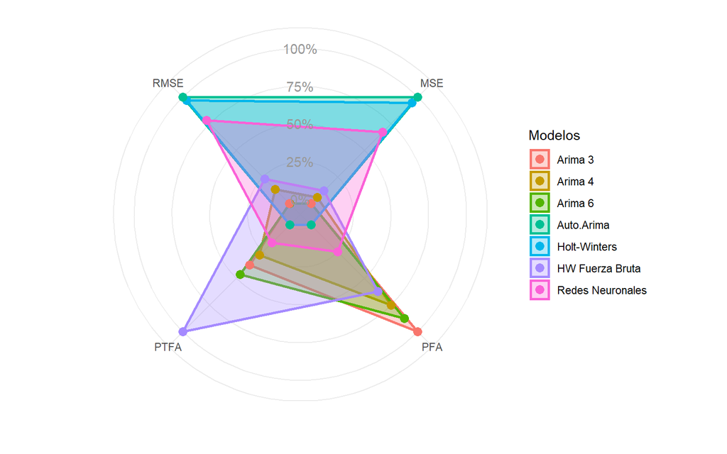

```r
grafico.errores(errores)
```

```r
# Primero unimos en una sola tabla la serie original con las predicciones.
serie.pred <- ts.union(serie.eth.train,
                       Original = serie.eth.test,
                       'Holt-Winters' = pred.holtw$mean,
                       'HW Fuerza Bruta' = pred.holtw.calibrado$mean,
                       'Redes Neuronales' = pred.nnet$mean,
                       'Auto.Arima' = pred.arima$pred,
                       'Arima 6' = pred.arima.6$mean,
                       'Arima 3' = pred.arima.3$mean,
                       'Arima 4' = pred.arima.4$mean)

serie.pred <- xts(xts(serie.pred, order.by = as.Date(dataset.eth$Date)))

dygraphs::dygraph(serie.pred, main = "Predicción del precio del Ethereum mensual con modelos avanzados", width = "100%") %>%
  dyRangeSelector() %>%
  dyLegend( width = 800) %>% #show = "follow",
  dyUnzoom() %>%
  dyCrosshair(direction = "vertical") %>%
  dyRangeSelector(height = 20, strokeColor = "black", fillColor = "black")
```

[interactive chart not shown]

## 4.9 **Selección del mejor modelo**

Seleccionamos el mejor modelo y realizamos una nueva predicción utilizando toda la serie de tiempo. En este caso utilizaremos Arima calibrado con el periodo 6.

```r
library(dygraphs)

metodo.arima.6 <- arima(serie.eth, order = c(1, 3, 3), seasonal = list(order = c(2, 2, 2), period = 6))

pred.arima.6 <- forecast(metodo.arima.6, h = 6, level = c(95))
pred.arima.6
```

```
##          Point Forecast    Lo 95    Hi 95
## Apr 2021       2229.696 1884.702 2574.690
## May 2021       2541.721 2012.822 3070.619
## Jun 2021       2878.960 2214.625 3543.295
## Jul 2021       3516.903 2716.992 4316.814
## Aug 2021       3910.791 2980.226 4841.357
## Sep 2021       4474.343 3406.616 5542.070
```

```r
prediccion <- ts.union(
  pred.arima.6 = pred.arima.6$mean, LimInf = pred.arima.6$lower, LimSup = pred.arima.6$upper
)

serie.final <- ts.union(serie.eth, prediccion)
head(serie.final)
```

```
##          serie.eth prediccion.pred.arima.6 prediccion.LimInf prediccion.LimSup
## Sep 2015  0.738644                      NA                NA                NA
## Oct 2015  0.916627                      NA                NA                NA
## Nov 2015  0.873119                      NA                NA                NA
## Dec 2015  0.933542                      NA                NA                NA
## Jan 2016  2.306040                      NA                NA                NA
## Feb 2016  6.336990                      NA                NA                NA
```

```r
fecha.fin <- dataset.eth$Date[nrow(dataset.eth)]
fechas <- fecha.fin + months(1:6)
total.fechas <- c(dataset.eth$Date, fechas)

serie.final <- xts(xts(serie.final, order.by = total.fechas))

dygraphs::dygraph(serie.final, main = "Predicción Ethereum para los próximos 6 meses", xlab = "Año", width = "100%") %>%
  dyAxis("y", label = "Precio($)") %>%
  dySeries(c("prediccion.LimInf", "prediccion.pred.arima.6", "prediccion.LimSup"), label = "Predicción") %>%
  dyLegend(show = "follow") %>%
  dyUnzoom() %>%
  dyCrosshair(direction = "vertical") %>%
  dyRangeSelector(height = 20, strokeColor = "black", fillColor = "black")
```

[interactive chart not shown]

# 5 **Evaluación final y conclusión**

A pesar de que podemos evaluar y medir la eficiencia de los modelos aplicados para la predicción de un posible precio para el Bitcoin y Ethereum, tenemos que considerar que este mundo de criptomonedas en relativamente nuevo y que con el pasar de los años podriamos obtener mejores predicciones en el futuro.

Si consideramos que el precio del Bitcoin, según, el modelo escogido estaría en **$75,965.58** para el próximo April 2021 y el precio del Ethereum estaría en **$2,229.7** para el mismo mes; al precio de hoy de estaríamos un poco lejos para lograr el precio predecido para Bitcoin y muy cerca para el precio de Ethereum. En resumen prodríamos decir que ambas predicciones muestran una tendencia al alza para los próximos meses.

A pesar que los datos son confiables, y en mi opinión, al ser un mercado muy volatil y que es afectado enormemente por los medios y noticias los modelos aplicados en este documento podrían quedarse corto para las futuras predicciones.

Mi recomendación para futuros ajustes, es obtener los datos más actualizado (como se realizó para este documento) y considerar ajustar los parámetros de calibración de arima con mayores valores lo cual implicaría realizarlo en un equipo informático con mejores prestaciones.

Para finalizar, si observamos la tendencia sobre los 12 años de existencia del Bitcoin, han existido periodos en el que el valor ha disminuído drásticamente. Sin embargo, se ha recuperado y más bien a triplicado su valor. Aunque el presente documento muestra una predición hacia arriba es posible que existan caídas, como han ocurrido en el pasado.

¡Invierta bajo su propio riesgo.!